# Kickstarter

Blake Brown and Jacob Fullerton

12/3/2018

```r
library(tidyverse)
library(readr)
library(caret)
library(keras)
library(vtreat)
library(randomForest)
library(gmodels)
library(doSNOW)
registerDoSNOW(makeCluster(2, type = "SOCK"))
library(ada)
data <- read_csv("data.csv")
data <- data %>% mutate(state=ifelse(state == 'canceled', 'failed', state))
data <- data %>% mutate(state=ifelse(state == 'live', 'successful', state))
data <- data %>% mutate(state=ifelse(state == 'suspended', 'failed', state))
data <- data %>% filter(state!='undefined')
#NHIS <- NHIS %>% mutate(SEX=ifelse(as.factor(SEX) == 1, 'MALE', 'FEMALE'))
#data <- data[1:15]
data$state <- as.factor(data$state)
data$category <- as.factor(data$category)
data$main_category <- as.factor(data$main_category)
data$currency <- as.factor(data$currency)
data$country <- as.factor(data$country)
summary(data)
```

```
##        ID                name                     category
##  Min.   :5.971e+03   Length:375099      Product Design: 22312
##  1st Qu.:5.381e+08   Class :character   Documentary   : 16138
##  Median :1.075e+09   Mode  :character   Tabletop Games: 14180
##  Mean   :1.075e+09                      Music         : 13494
##  3rd Qu.:1.610e+09                      Shorts        : 12357
##  Max.   :2.147e+09                      Video Games   : 11830
##                                         (Other)       :284788
##       main_category       currency         deadline
##  Film & Video: 62731   USD    :292795   Min.   :2009-05-03
##  Music       : 49684   GBP    : 33696   1st Qu.:2013-06-01
##  Publishing  : 39412   EUR    : 17243   Median :2015-01-06
##  Games       : 35230   CAD    : 14761   Mean   :2014-10-30
##  Technology  : 32566   AUD    :  7847   3rd Qu.:2016-05-02
##  Design      : 30068   SEK    :  1758   Max.   :2018-03-03
##  (Other)     :125408   (Other):  6999
##       goal             launched                      pledged
##  Min.   :0.00e+00   Min.   :1970-01-01 01:00:00   Min.   :       0
##  1st Qu.:2.00e+03   1st Qu.:2013-05-01 04:56:43   1st Qu.:      31
##  Median :5.50e+03   Median :2014-12-02 23:36:34   Median :     620
##  Mean   :4.95e+04   Mean   :2014-09-26 12:23:20   Mean   :    9753
##  3rd Qu.:1.65e+04   3rd Qu.:2016-03-30 06:20:10   3rd Qu.:    4080
##  Max.   :1.00e+08   Max.   :2018-01-02 15:02:31   Max.   :20338986
##
##         state           backers            country
##  failed    :238344   Min.   :     0.0   US     :292627
##  successful:136755   1st Qu.:     2.0   GB     : 33672
##                      Median :    12.0   CA     : 14756
##                      Mean   :   106.6   AU     :  7839
##                      3rd Qu.:    57.0   DE     :  4171
##                      Max.   :219382.0   FR     :  2939
##                                         (Other): 19095
##   usd pledged       usd_pledged_real   usd_goal_real
##  Min.   :       0   Min.   :       0   Min.   :        0
##  1st Qu.:      17   1st Qu.:      31   1st Qu.:     2000
##  Median :     395   Median :     625   Median :     5500
##  Mean   :    7037   Mean   :    9124   Mean   :    45847
##  3rd Qu.:    3034   3rd Qu.:    4050   3rd Qu.:    16000
##  Max.   :20338986   Max.   :20338986   Max.   :166361391
##  NA's   :235
```

```r
#View(data)

#data[which(data$pledged >= data$usd_goal_real)]
```

```r
outcome <- 'state'
target <- 2
tooDetailed <- c("name")
vars <- setdiff(colnames(data), c(tooDetailed))
dTrain <- data
```

```r
set.seed(4623762)
tplan <- vtreat::designTreatmentsZ(dTrain, vars,
                                   minFraction= 0,
                                   verbose=FALSE)
# restrict to common varaibles types
# see vignette('vtreatVariableTypes', package = 'vtreat') for details
sf <- tplan$scoreFrame
newvars <- sf$varName[sf$code %in% c("lev", "clean", "isBAD")]
trainVtreat <- as.matrix(vtreat::prepare(tplan, dTrain,
                                         varRestriction = newvars))
print(dim(trainVtreat))
```

```
## [1] 375099    223
```

```r
output <- as.data.frame(trainVtreat)
dataNew <- output
#print(colnames(dataNew))
```

```r
set.seed(124)
ind <- createDataPartition(dataNew$state_lev_x_successful, p=0.8, list = FALSE)
dataNew <- dataNew[-199]
#print(colnames(dataNew))
x_train <- dataNew[ind,-199]
x_train_label <- dataNew[ind,199]
x_train_label <- as.data.frame(x_train_label)
x_test <- dataNew[-ind,-199]
x_test <- as.data.frame(x_test)
x_test_label <- dataNew[-ind,199]
x_test_label <- as.data.frame(x_test_label)

#x_train_label <- as.factor(x_train_label)
#x_test_label <- as.factor(x_test_label)
```

```r
# Normalize training data
x_train <- scale(x_train)

# Use means and standard deviations from training set to normalize test set
col_means_train <- attr(x_train, "scaled:center")
col_stddevs_train <- attr(x_train, "scaled:scale")
x_test <- scale(x_test)
```

Now we define our model (using keras syntax):

```r
network <- keras_model_sequential() %>% layer_dense(units = 200, activation = "relu", input_shape = dim(x_train)[2]) %>% layer_dense(units = 100, activation = "relu") %>% layer_dense(units = 8, activation = "relu") %>%layer_dense(units = 8, activation = "relu") %>%layer_dense(units = 8, activation = "relu") %>%layer_dense(units = 1, activation = "sigmoid")
```

Now we need to compile our model, determining our optimizer (e.g., gradient descent), our loss function (e.g., sum of squared error) and the metric by which to measure our performance (e.g., accuracy)

```r
network %>% compile(loss = "binary_crossentropy", optimizer = optimizer_adam(lr = 0.0005), metrics = c("binary_accuracy"))
```

Now we fit the model:

```r
x_train <- as.matrix(x_train)
x_train_label <- as.matrix(x_train_label)
network %>% fit(x_train,x_train_label, epochs = 10)#, batch_size=10)
```

```r
x_test <- as.matrix(x_test)
x_test_label <- as.matrix(x_test_label)
metrics <- network %>% evaluate(x_test,x_test_label)
metrics
```

```
## $loss
## [1] 0.201585
##
## $binary_accuracy
## [1] 0.9187273
```

### Random Forest Model

```r
set.seed(1234)
ind <- createDataPartition(data$state, p =.8, list = FALSE)
train <- data[ind,-c(1,2,3)]
test <- data[-ind,-c(1,2,3)]
train <- na.omit(train)
test <- na.omit(test)
str(train)
```

```
## Classes 'tbl_df', 'tbl' and 'data.frame':    299890 obs. of  12 variables:
##  $ main_category   : Factor w/ 15 levels "Art","Comics",..: 13 7 11 7 8 8 8 5 7 13 ...
##  $ currency        : Factor w/ 14 levels "AUD","CAD","CHF",..: 6 14 14 14 14 14 14 14 14 2 ...
##  $ deadline        : Date, format: "2015-10-09" "2013-02-26" ...
##  $ goal            : num  1000 45000 5000 19500 50000 1000 25000 125000 65000 2500 ...
##  $ launched        : POSIXct, format: "2015-08-11 12:12:28" "2013-01-12 00:20:50" ...
##  $ pledged         : num  0 220 1 1283 52375 ...
##  $ state           : Factor w/ 2 levels "failed","successful": 1 1 1 1 2 2 1 1 1 1 ...
##  $ backers         : int  0 3 1 14 224 16 40 58 43 0 ...
##  $ country         : Factor w/ 23 levels "AT","AU","BE",..: 10 23 23 23 23 23 23 23 23 4 ...
##  $ usd pledged     : num  0 220 1 1283 52375 ...
##  $ usd_pledged_real: num  0 220 1 1283 52375 ...
##  $ usd_goal_real   : num  1534 45000 5000 19500 50000 ...
##  - attr(*, "na.action")= 'omit' Named int  1927 3879 4250 4448 6553 8381 8895 11416 11528 13320 ...
##   ..- attr(*, "names")= chr  "1927" "3879" "4250" "4448" ...
```

```r
randomForest_model <- randomForest(train[,-7],
                                   train$state,
                                   sampsize = round(0.6*(length(train))), ## the number of sample size
                                   ntree = 2000, ## How many trees to use
                                   mtry = sqrt(9),
                                   importance = TRUE) ## Good for feature selection
tables <- CrossTable(train$state, randomForest_model$predicted,
                     prop.chisq = FALSE, prop.c = FALSE, prop.r = FALSE,
                     dnn = c('actual survived', 'predicted survived'))
```

```
##
##
##    Cell Contents
## |-------------------------|
## |                       N |
## |         N / Table Total |
## |-------------------------|
##
##
## Total Observations in Table:  299890
##
##
##                 | predicted survived
## actual survived |     failed | successful |  Row Total |
## ----------------|------------|------------|------------|
##          failed |     170126 |      20446 |     190572 |
##                 |      0.567 |      0.068 |            |
## ----------------|------------|------------|------------|
##      successful |      23224 |      86094 |     109318 |
##                 |      0.077 |      0.287 |            |
## ----------------|------------|------------|------------|
##    Column Total |     193350 |     106540 |     299890 |
## ----------------|------------|------------|------------|
##
##
```

```r
tables$prop.tbl[1] + tables$prop.tbl[4]
```

```
## [1] 0.8543799
```

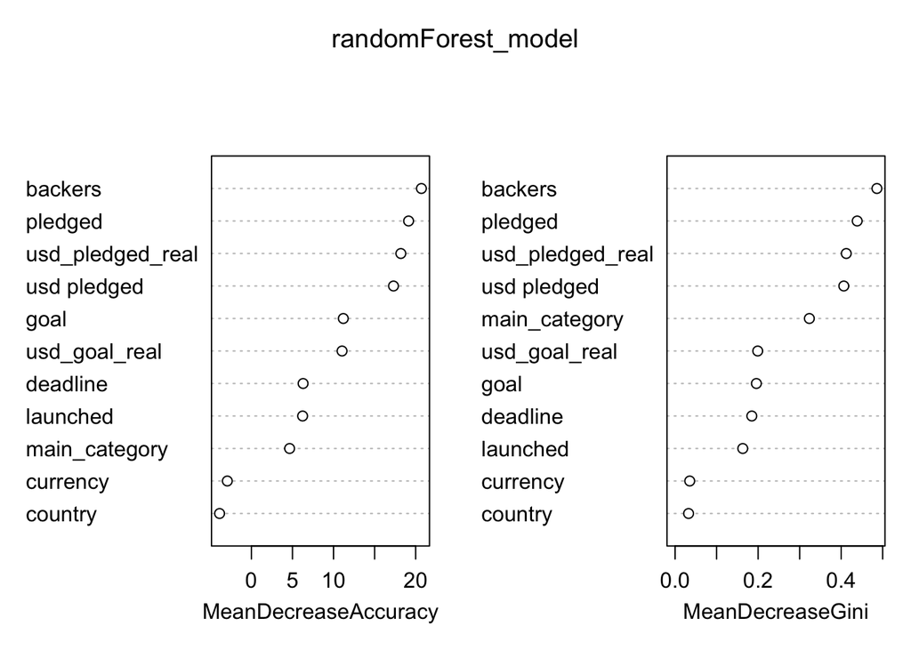

```r
varImpPlot(randomForest_model)
```

From the variable importance plot it appears as though we should remove currency and country from the model

```r
str(train)
```

```
## Classes 'tbl_df', 'tbl' and 'data.frame':    299890 obs. of  12 variables:
##  $ main_category   : Factor w/ 15 levels "Art","Comics",..: 13 7 11 7 8 8 8 5 7 13 ...
##  $ currency        : Factor w/ 14 levels "AUD","CAD","CHF",..: 6 14 14 14 14 14 14 14 14 2 ...
##  $ deadline        : Date, format: "2015-10-09" "2013-02-26" ...
##  $ goal            : num  1000 45000 5000 19500 50000 1000 25000 125000 65000 2500 ...
##  $ launched        : POSIXct, format: "2015-08-11 12:12:28" "2013-01-12 00:20:50" ...
##  $ pledged         : num  0 220 1 1283 52375 ...
##  $ state           : Factor w/ 2 levels "failed","successful": 1 1 1 1 2 2 1 1 1 1 ...
##  $ backers         : int  0 3 1 14 224 16 40 58 43 0 ...
##  $ country         : Factor w/ 23 levels "AT","AU","BE",..: 10 23 23 23 23 23 23 23 23 4 ...
##  $ usd pledged     : num  0 220 1 1283 52375 ...
##  $ usd_pledged_real: num  0 220 1 1283 52375 ...
##  $ usd_goal_real   : num  1534 45000 5000 19500 50000 ...
##  - attr(*, "na.action")= 'omit' Named int  1927 3879 4250 4448 6553 8381 8895 11416 11528 13320 ...
##   ..- attr(*, "names")= chr  "1927" "3879" "4250" "4448" ...
```

```r
randomForest_model <- randomForest(train[,-c(2,7,9)],
                                   train$state,
                                   sampsize = round(0.6*(length(train))), ## the number of sample size
                                   ntree = 2000, ## How many trees to use
                                   mtry = sqrt(9),
                                   importance = TRUE) ## Good for feature selection
tables <- CrossTable(train$state, randomForest_model$predicted,
                     prop.chisq = FALSE, prop.c = FALSE, prop.r = FALSE,
                     dnn = c('actual survived', 'predicted survived'))
```

```
##
##
##    Cell Contents
## |-------------------------|
## |                       N |
## |         N / Table Total |
## |-------------------------|
##
##
## Total Observations in Table:  299890
##
##
##                 | predicted survived
## actual survived |     failed | successful |  Row Total |
## ----------------|------------|------------|------------|
##          failed |     168430 |      22142 |     190572 |
##                 |      0.562 |      0.074 |            |
## ----------------|------------|------------|------------|
##      successful |      21322 |      87996 |     109318 |
##                 |      0.071 |      0.293 |            |
## ----------------|------------|------------|------------|
##    Column Total |     189752 |     110138 |     299890 |
## ----------------|------------|------------|------------|
##
##
```

```r
tables$prop.tbl[1] + tables$prop.tbl[4]
```

```
## [1] 0.8550669
```

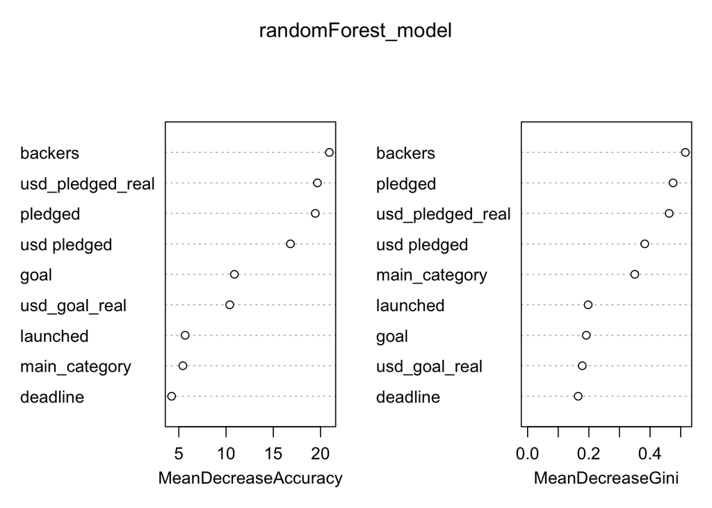

```r
varImpPlot(randomForest_model)
```

With this model we get an accuracy of about .85, which isn’t too bad, lets see how it performs on the test data

```r
pred <- predict(randomForest_model, test)
tables <- CrossTable(test$state, pred,
                     prop.chisq = FALSE, prop.c = FALSE, prop.r = FALSE,
                     dnn = c('actual survived', 'predicted survived'))
```

```
##
##
##    Cell Contents
## |-------------------------|
## |                       N |
## |         N / Table Total |
## |-------------------------|
##
##
## Total Observations in Table:  74974
##
##
##                 | predicted survived
## actual survived |     failed | successful |  Row Total |
## ----------------|------------|------------|------------|
##          failed |      42075 |       5568 |      47643 |
##                 |      0.561 |      0.074 |            |
## ----------------|------------|------------|------------|
##      successful |       5389 |      21942 |      27331 |
##                 |      0.072 |      0.293 |            |
## ----------------|------------|------------|------------|
##    Column Total |      47464 |      27510 |      74974 |
## ----------------|------------|------------|------------|
##
##
```

```r
tables$prop.tbl[1] + tables$prop.tbl[4]
```

```
## [1] 0.853856
```

Also about 85% accuracy which is fairly good, however lets see if we can get a better accuracy by tuning our hyper parameters

```r
cv_opts <- trainControl(method="cv", number=10)
Grid <- expand.grid(mtry = seq(1,10))
results_rf <- train(train[,-c(2,7,9)], train$state  ,data=train, method="rf",
                    trControl=cv_opts, # Cv opts is for tuning hyperparameteres
                    tuneGrid=Grid)
pred <- predict(results_rf, test)
tables <- CrossTable(test$state, pred,
                     prop.chisq = FALSE, prop.c = FALSE, prop.r = FALSE,
                     dnn = c('actual survived', 'predicted survived'))
tables$prop.tbl[1] + tables$prop.tbl[4]
```

[output not shown]

### Adaptive Boosting Model

```r
cv_opts <- trainControl(method="cv", number=5)
Grid <- expand.grid(maxdepth=c(3,4,5,6,7),nu=.01,iter=c(50,100,150,200))
results_ada <- train(state~., data=train, method="ada",
                    trControl=cv_opts,tuneGrid=Grid)
```